# Wildlife surveillance survey - Guinea Results

## Section A: General Section

- 5 Respondents from 5 institutions
- 100% used excel to fulfill the questionnaire

### Participating institutions

| Name of Institution | Freq |
| --- | --- |
| Centre de Recherche et de Formation en Infectiologie de Guinée (CERFIG) | 1 |
| EBO SURSY | 1 |
| Guinée Ecologie | 1 |
| Ministry of the Environment | 1 |
| PREDICT | 1 |

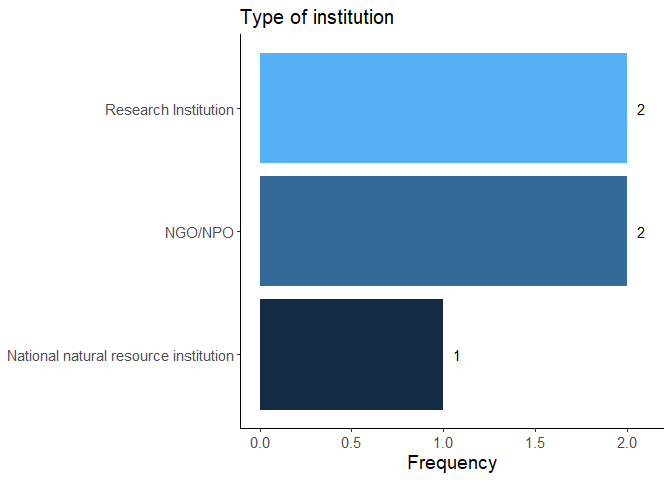

**Reported limitations for the sharing of information between public and private entities:**

| Reported Limitations |
| --- |
| After validation of health information, information is shared with all stakeholders involved in surveillance |
| Confidentiality clauses |

- Note: No confidentiality issues reported when specifically asked

### Number of participants that have data on the sections

| Sections | Frequency |
| --- | --- |
| B- Data on the farming and trade of wild mammals and birds | 2 |
| C- Data on distribution and movement of wild mammals and birds | 3 |
| D- Data on the health and infectious diseases in wild mammals and birds | 3 |
| E- Outbreak investigations involving wildlife | 4 |
| F- Trainings or guidelines on wild mammals and wild birds health | 3 |

**By type of training**

| Training or guidelines on | Frequency |
| --- | --- |
| F.1: Diseases of wildlife | 1 |
| F.2: Capture and manipulation of wildlife | 2 |
| F.3: Collection, handling, transportation, and storage of clinical samples | 2 |
| F.4: Collection, handling, transportation and storage of environmental samples | 1 |
| F.5: Necropsy of wildlife | 1 |
| F.6: Laboratory tests for infectious diseases in wildlife | 2 |
| F.7: Biosafety/biosecurity measures involving wildlife | 3 |

### Activities and institutions

**Institutions that have data on farming and trade:**

| Institutions that have data on Farming and Trade | Number of activities |
| --- | --- |
| EBO SURSY | 1 |
| Ministry of the Environment | 1 |

**Institutions that have data on distribution and movement of wild mammals and birds**

| Institutions that have data on distribution and movement | Number of activities |
| --- | --- |
| EBO SURSY | 1 |
| Guinée Ecologie | 1 |
| Ministry of the Environment | 1 |

**Institutions that have data on the health and infectious diseases in wild mammals and birds**

| Institutions that have data on the health and infectious diseases | Number of activities |
| --- | --- |
| Centre de Recherche et de Formation en Infectiologie de Guinée (CERFIG) | 1 |
| EBO SURSY | 1 |
| Ministry of the Environment | 1 |

**Institutions that have participated on outbreak investigations involving wildlife**

| Institutions that have data on outbreak investigations | Number of activities |
| --- | --- |
| Centre de Recherche et de Formation en Infectiologie de Guinée (CERFIG) | 1 |
| EBO SURSY | 1 |
| Ministry of the Environment | 1 |
| PREDICT | 1 |

**Institutions that have delivered or developed training or guidelines about wild mammals and wild birds health**

| Institutions that have have delivered or developed trainings or guidelines | Number of activities |
| --- | --- |
| EBO SURSY | 7 |
| PREDICT | 4 |
| Ministry of the Environment | 1 |

#### Section G: Other institutions suggested

3 New institutions identified:

- Ministère de l’Elélévage
- IRD
- Centre de Recherche et de Formation en Infectiologie de Guinée (CERFIG)

## Section B: Data on the Farming and Trade of wild mammals and birds

2 activities reported. One from EBO SURSY and One from the Ministry of the Environment:

- EBO SURSY collected data about live animals and meat or other products consumed as food, specifically regarding mammals, to gather all parameters on domestic and wild animals at borders and at livestock and poultry markets. The data was collected regarding price, demand, consumer characterization, and wildlife markets, in a sub national level. Data is shared with government entities, in a “One healh approach”, by administrative means, when there is data to share. These information are used to facilitate decision-making.
- The Ministry of the Environment collected data specifically about primates, Cephalophus, and Potamochoerus. Regarding the trade of Ornamental products (e.g. ivory, feathers, shells). The data was also part of a value chain studies, that was done in the prectures (districts) of mamou (myenne guinea), macenta (forest guinea), kankan, siguiri and mandiana (upper guinea). Aimed at changing social behavior and reducing transmission of zoonotic diseases. Data were collected in a subnational level, and shared with other government entities (Ministries of Health and Livestock, and the OH platform), through reports, at a regular basis. Data is used in areas of awareness-raising campaigns.

#### B 1:Is the data on the trade or farming of a specific species, genus, family or order of wild mammal or bird?

- Note: Both answered yes, but when asked to specify, one of the respondents reported to collect data on “Mammals”, not a specific order, as showed below.

**B 1.1:If yes, what is the species, genus, family, or order of the animals on which data is collected?**

| species, genus, family, or order of the animals |
| --- |
| Mammals |
| Primates, Cephalophus, Potamochoerus |

#### B 2: Is data collected on live animals or on specific products?

| Institution | Live animals or specific products the data is collect |
| --- | --- |
| EBO SURSY | Live animals and Meat or other products consumed as food |
| Ministry of the Environment | Ornamental products (e.g. ivory, feathers, shells) |

#### B 3: Is any data on infectious diseases or health also collected (e.g. Avian influenza, Hendra virus, etc.)? If yes, please make sure to fill in a separate row in sheet D of this questionnaire afterwards that is specifically related to wildlife health more ahead.

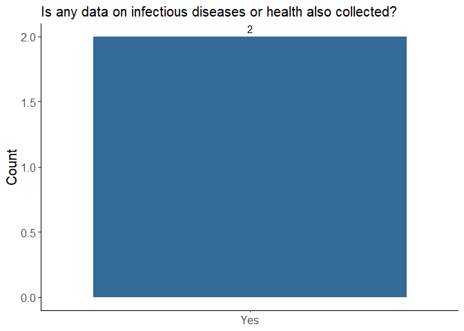

- note: Both participants added information on section D.

#### B 4: Please select all options that apply to the type of data collected regarding the trade or farming of wildlife.

| Institution | Type of data collected |
| --- | --- |
| EBO SURSY | Price, Demand, Consumer characterization, Wildlife markets |
| Ministry of the Environment | Trade in animal products |

**B 4.2:Please provide more details on the type of data collected regarding the trade or farming of wildlife**

| Institution | Details on the type of data collected |
| --- | --- |
| EBO SURSY | Mobility of domestic and wild animals |
| Ministry of the Environment | Products are sold in markets for local consumption |

#### B 6: Is this data collected as part of a value chain study? Value chain studies analyze the economic activities and interactions between actors involved in the production and trade of commodities or products.

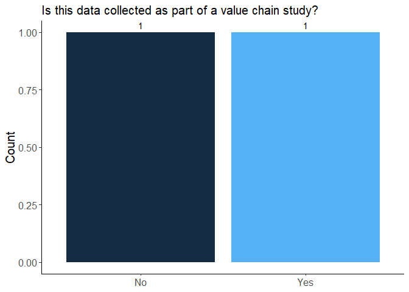

**B 7: If yes, please describe briefly the value chain study where this data is used.**

| Institution | Value chain study where this data is used |
| --- | --- |
| Ministry of the Environment | the value study of the trade in animal vianades was done in the prectures (districts) of mamou (myenne guinea), macenta (forest guinea), kankan, siguiri and mandiana (upper guinea). Aimed at changing … |

#### B 8: At what geographic level is this data collected?

Both institutions collected data at a Sub national level (province, state, city, etc)

**B 8.1: Please specify the countries, subnational levels (province, state, cities, etc.) and/or specific sites (market, park, interfaces between park/reserve, etc.) where data is collected.**

- Note: No one provided specific information.

Ministry of the Environment reported to collect data on market and provinces

- 1 NA

#### B 9/ B 9.1: Start and end date of data collection

| Institution | Start date | End date |
| --- | --- | --- |
| Ministry of the Environment | 12-03-2020 | 15-05-2020 |

- Note: one respondent replied “July and September”, without specifying the year.

#### B 10: Where is the data stored? Please select all that apply

| Institution | Where is the data stored? |
| --- | --- |
| EBO SURSY | Paper-based (not digitized) |
| Ministry of the Environment | Paper-based and Digitally stored in a local server |

#### B 11: How is this data used?

| Institution | How is this data used? |
| --- | --- |
| EBO SURSY | Facilitate decision-making |
| Ministry of the Environment | Awareness-raising campaigns |

#### B 13: Is data from this activity shared with any government entity?

- Both institutions share data with government entities

**B 13.1: If yes, please specify which entity**

| Institution | Entities the data is shared with |
| --- | --- |
| Ministry of the Environment | Ministries (Health, livestock) and OH platform |

- Note: One respondent didn’t specify the entity, replied only that it was in a “One health approach”

#### B 13.2: How is the data shared with government entity(ies)?

| Institution | How is the data shared? |
| --- | --- |
| EBO SURSY | By administrative means |
| Ministry of the Environment | Bulletin |

#### B 13.3: How often is the data shared with government entity(ies)?

| Institution | How often is the data shared |
| --- | --- |
| EBO SURSY | Ad hoc/when there is data to share |
| Ministry of the Environment | Weekly |

## Section C: Data on distribution and movement of wild mammals and birds

3 activities reported in the section:

- EBO SURSY collected data from animals in Rehabilitation center and Natural habitat, regarding animal movements, demographic data and Community wildlife management, with the goal of collecting health information. Data are collected at Community level and reported to the sub-prefecture, prefecture and central level and shared with OH platform By administrative means and internet when there is data available.
- Ministry of the Environment collected data about Phacochoerus from Natural Habitat, Parks and around Protected Areas, regarding the dstribution of suitable habitats for certain animals and Community Reserves. Data are collected at Sub-national, and used by the actors in awareness-raising, capacity building and cross-borde. Data is shared through reports regularly (Weekly)
- Guinée Ecologie collected data about Pan troglodytes verus from its Natural habitat, with the goal of identifying viable habitats for chimpanzees and understanding the Cohabitation between chimpanzees and local communities. Data is collected at a Sub-national level, specifically from the prefectures of Gaoual, Koundara, Kindia, Telimele, Dabola and Dinguiraye. Data is used to contribute for the conservation of chimpanzees, and shared with the Ministry of Environment, Water and Forestry ad hoc, in meetings and workshops.

#### C_1: Is data collected on a specific species, genus, family, or order of wild mammal or bird?

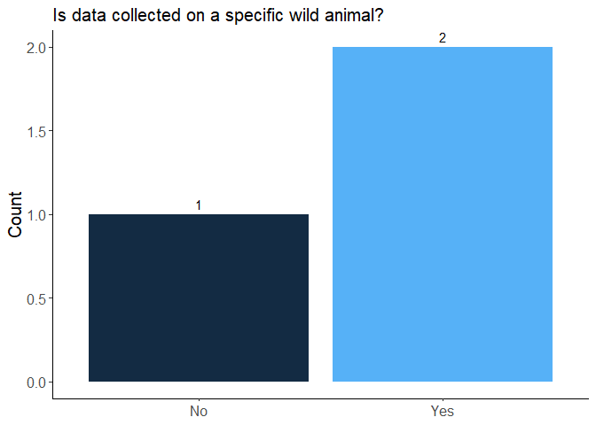

**C_1.1: If yes, please specify the targeted species, genus, family, or order of wild mammal or bird**

| Institution | species, genus, family, or order of the animals |
| --- | --- |
| Ministry of the Environment | Phacochoerus |
| Guinée Ecologie | Pan troglodytes verus |

#### C_2: Please specify the type of environment of the animals on which data is being collected. Please select all that apply

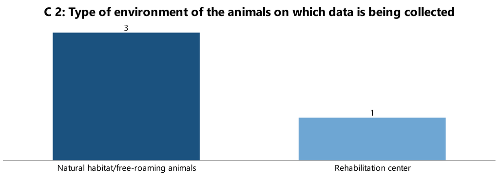

- Note: All 3 institutions collected data on Free roaming animals, EBO SURSY also collected data on animals in Rehabilitation centers.

#### C_3: Please select the type of data that is being collected. Please select all that apply

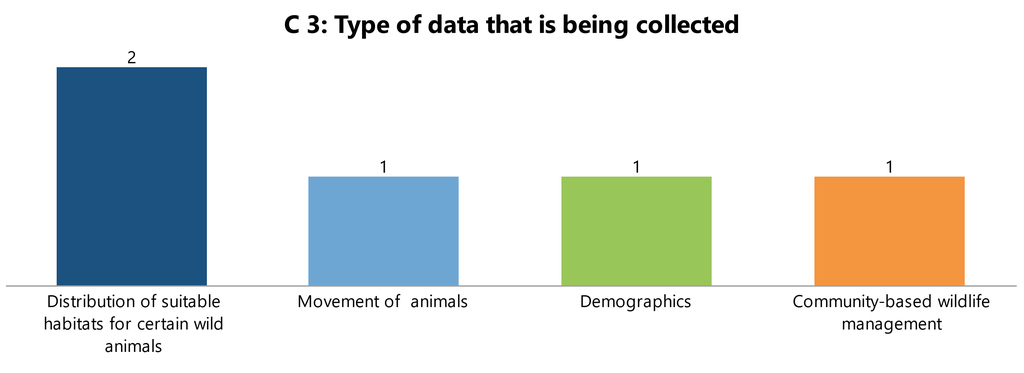

- Note: Guinée ecologie and the Ministry of the environment collected data on Distribution of suitable habitats for animals. While EBO SURSY collected data on Animal movements, demographics and community based wildlife management.

**C_3.1: If Other, please specify**

| Institution | Other types of data collected |
| --- | --- |
| Ministry of the Environment | Community Reserves |

Note: the respondent that replied to this question didn’t select the “Other” option in the previous question.

**C_3.2: Please provide more details on the type of data collected**

| Institution | Details on the type of data collected |
| --- | --- |
| Guinée Ecologie | Identification of viable habitats for chimpanzees; cohabitation between chimpanzees and local communities |

#### C_4: At what geographic level is this data collected?

the data from all 3 activities were collected at Subnational level

**C_4.1: Please specify the countries, subnational levels (province, state, cities, etc.) and/or specific sites (specific park) where data is collected.**

| Institution | Specific subnational level and/or specific sites where data is collected |
| --- | --- |
| Guinée Ecologie | The prefectures of Gaoual, Koundara, Kindia, Telimele, Dabola and Dinguiraye |

- Note: The Ministry of Environment reported to collect data on “Provinces, cities and parks”.

1 NA

#### C_5: Does this activity also include data on infectious diseases?

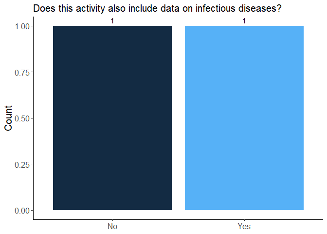

EBO SURSY replied Yes, Guinée Ecologie replied No.

#### C_6, C_.1 and C_6.2: Start and end date of data collection

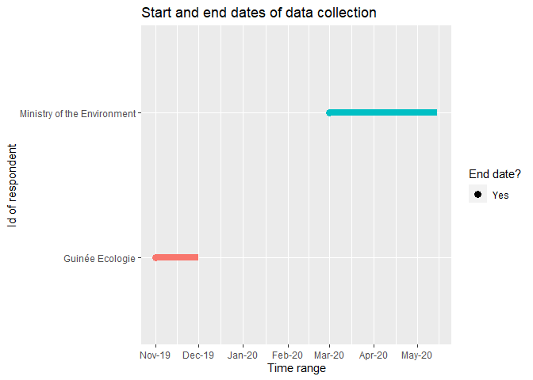

- Note: 1 NA

#### C_8: Please describe briefly how this data is used

| Institution | How is this data used? |
| --- | --- |
| EBO SURSY | Data are collected at Community level and reported to the sub-prefecture, prefecture and central level |
| Ministry of the Environment | They are used by the actors in awareness-raising, capacity building and cross-border meetings |
| Guinée Ecologie | Conservation planning |

#### C_10: Where is the data stored? Please select all that apply

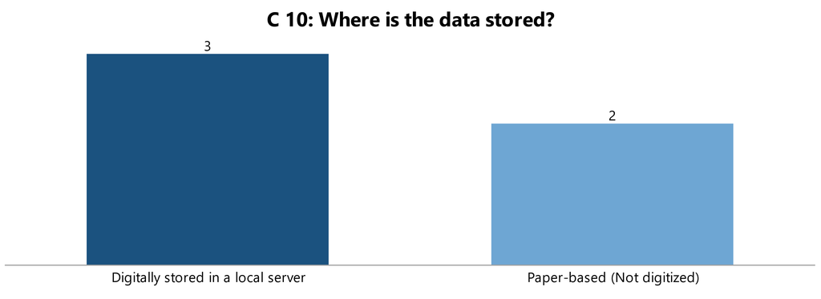

- Note: All 3 activities had data digitally stored in a local server, 2 activities (from EBO SURSY and Guinée Ecologie) also stored data in paper.

#### C_11: Is data from this activity shared with any government entity?

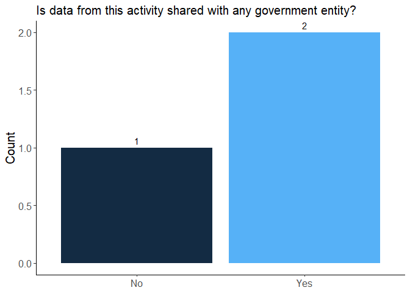

- note: the respondent that answered No in this question, added in the next question (Specify which entity), that the data was shared with the ministry of environment. So perhaps the “No” was a mistake.

**C_11.1: If yes, please specify which entity**

| Institution | Entities the data is shared with |
| --- | --- |
| EBO SURSY | OH platform |
| Guinée Ecologie | Ministry of Environment, Water and Forestry |

- note: 1 NA (from the Ministry of the Environment)

**C_11.2: How is the data shared?**

| Institution | How is the data shared? |
| --- | --- |
| EBO SURSY | By administrative means |
| Ministry of the Environment | Bulletin |
| Guinée Ecologie | In meetings or workshops |

**C_11.3: How often is the data shared?**

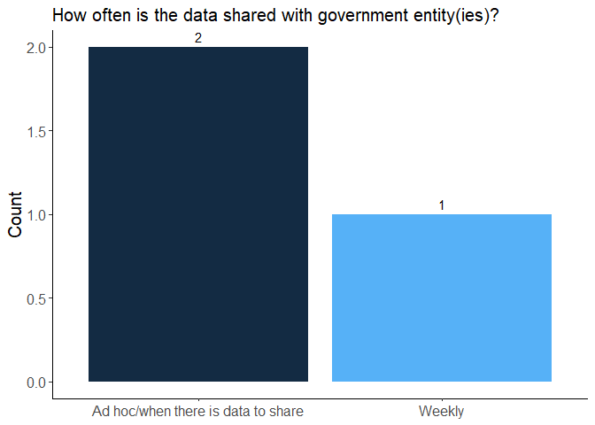

- Note: The ministry of environment shares data regularly (Weekly), while EBO SURSY and Guinée Ecologia share data ad hoc

## Section D: Data on the health of wild mammals and birds

3 activities reported:

#### D_1: Is the data related to live animals or to animal products?

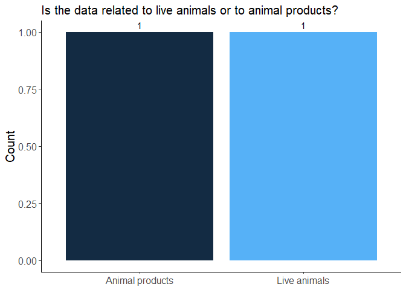

- note: EBO SURSY collected data on Live animals, while the Ministry of the Environment on Animal products. CERFIG replied “All captured bat species are involved”.

**D_1.1: If related to an animal product, please specify the type of animal product**

| Institutions | Type of animal product |
| --- | --- |
| CERFIG | Oral and rectal swabs, blood, hair and organs |
| Ministry of the Environment | Smoked meat |

#### D_2: In what type of wildlife is data collected? Please select all that apply

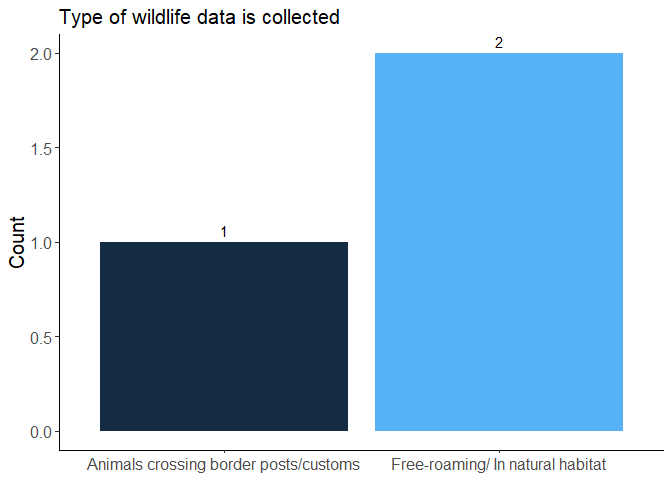

- Note: EBO SURSY collected data from Animals crossing border posts/customs, and CERFIG and The Ministry of the Environment collected data on Free-roaming animals.

#### D_2.2: What was the targeted species, genus, family or order of wild mammal or bird

| Institution | species, genus, family, or order of the animals |
| --- | --- |
| Ministry of the Environment | Cephalophus spp, Potamochoerus spp., Phacochoerini spp., Tragelaphus scriptus,etc |

- Note: 2 NA

#### D_3: Is the data on a specific syndrome or disease or group of diseases?

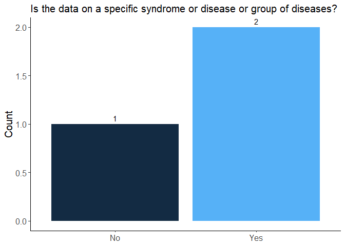

**D_3.1: If yes, what is the targeted syndrome or disease?**

| Institution | Targeted syndrome or disease |
| --- | --- |
| CERFIG | Viral hemorrhagic fevers of Ebola, Marburg, rift valley, Crimé-Congo and Lassa |
| Ministry of the Environment | Ebola virus hemorrhagic fever, Lassa fever |

#### D_3.2: Was the disease or pathogen confirmed using a lab-based diagnosis?

- Note: Only the Ministry of the Environment replied yes

2 NA

**D_3.2.a: If laboratory-based diagnosis, what type of samples were collected? Please select all that apply**

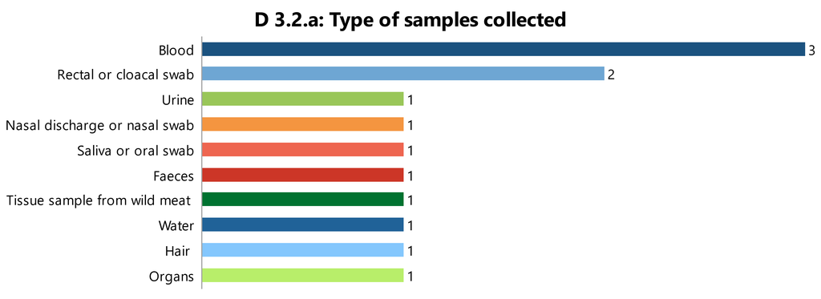

- Note: All institutions replied to have collected blood. Rectal or cloacal swab were collected by EBO SURSY and CERFIG. EBO SURSY also collected faeces , urine , nasal discharge or nasal swab, Bushmeat tissue and Water. Besides blood and rectal or cloacal swab, CERFIG collected hair and organs.

**D_3.2.b: What type of diagnostic method was used to analyse the sample? Please select all that apply**

| Institution | Type of diagnostic method used to analyse the sample |
| --- | --- |
| EBO SURSY | Serological and Pathogen detection |
| Ministry of the Environment | Pathogen detection |

1 NA

**D_3.2.b.i: Please specify the tests that were used to analyse the sample**

3 NA

**D_3.2.c: Was the diagnostic test validated for the targeted animal? Validation is a process that determines the fitness of an assay, which has been properly developed, optimised and standardised, for an intended purpose (OIE, 2018)**

- EBO SURSY replied “I don’t know”

2 NAs

**D_3.2.d: In which type of laboratory is this diagnosis done? Please select all that apply**

| Institution | Type of laboratory |
| --- | --- |
| EBO SURSY | National Laboratory of the Ministry of Livestock/Agriculture or similar |

- Note: The respondent of the Ministry of Environment replied: “Validated by (California laboratory) through the PRETICT (Ebola virus hemorrhagic fever) projects”

1 NA

**D_3.2.d.ii: Please specify the name of the laboratory where these samples were tested**

| Institutions | Name of the laboratory where these samples were tested |
| --- | --- |
| EBO SURSY | LCVD and regional laboratories |
| Ministry of the Environment | California Laboratory |

1 NA

#### D_4 to D_4.2:What is the start date and end date of this data collection?

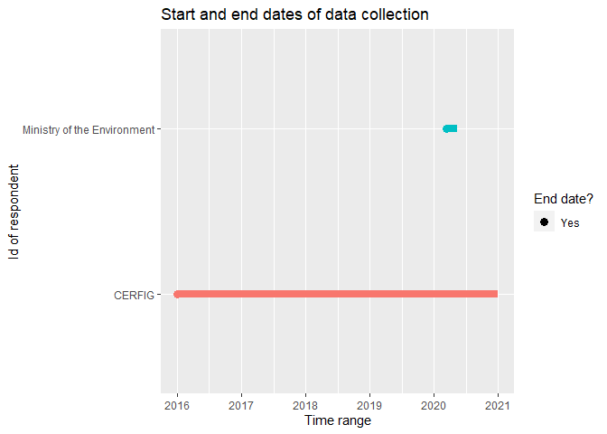

| Institution | Start date | End date |
| --- | --- | --- |
| Ministry of the Environment | 2020-03-13 | 2020-05-13 |
| CERFIG | 2016-01-01 | 2021-01-01 |

- Note: 1 NA

#### D_6: Is this data collection on health or infectious diseases part of another activity, including any previously mentioned activities (e.g. related to monitoring of traded wildlife, related to monitoring programme on wildlife distribution, etc.)

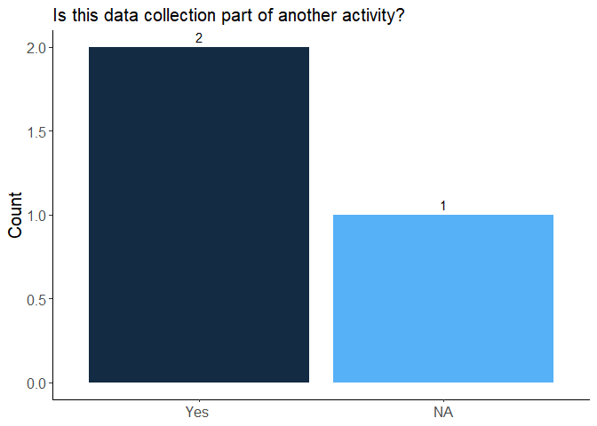

- EBO SURSY and The Ministry of the Environment replied “Yes”

**D_6.1:If yes, please describe briefly the activity it is part of**

| Institutions | Description of the activity |
| --- | --- |
| EBO SURSY | Rapid detection of health events |
| Ministry of the Environment | Surveillance of priority zoonoses in Guinea community, sub-prefectural, prefectural, regional and national level with all the actors of the OH platform |

1 NA

#### D_7:Please describe briefly how this data is used (e.g. guide vaccination plan, guide livestock surveillance, etc.)

| Institutions | How data is used |
| --- | --- |
| EBO SURSY | Develop a TOR and its budget for a vaccination program and risk-based surveillance (active surveillance) |
| Ministry of the Environment | Guide risk monitoring |

1 NA

#### D_9:Where is the data stored? Please select all that apply

| Institution | Where is the data stored? |
| --- | --- |
| EBO SURSY | Paper-based (not digitized) and Digitally stored in a local server |
| Ministry of the Environment | Paper-based |

1 NA

#### D_10:Is data from this activity shared with any government entity? If no, please jump to question 10.4.

- EBO SURSY and The Ministry of the Environment replied “Yes”

1 NA

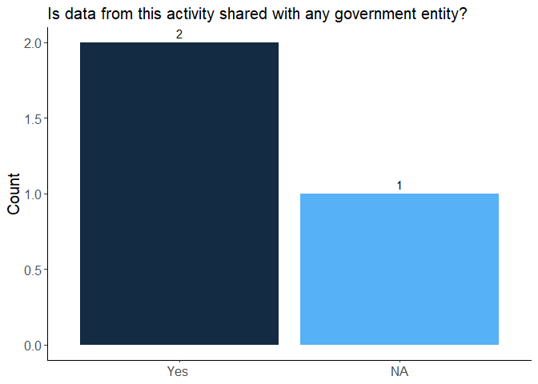

**D_10.1:If yes, please specify which entity (e.g. Ministry of Agriculture, Ministry of the Environment, National One Health Platform, etc.). Please use the exact name of the entity(ies) in your country.**

| Institution | Entities the data is shared with |
| --- | --- |
| Ministry of the Environment | Ministry of Elevation, Ministry of the Environment, One Health Platform |

- Note: 1 NA, EBO SURSY replied only “Platform”

#### D_10.2:How is the data shared?

The Ministry of Environment shares data through Newsletters and e-mails.

2 NA

#### D_10.3:How often is the data shared?

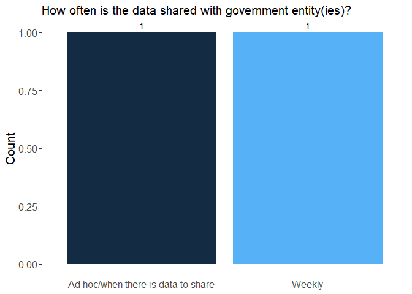

- Note: The ministry of environment shares data regularly (Weekly), while EBO SURSY share data ad hoc 1 NA

## Section E - Outbreak investigation involving wildlife

4 activities reported:

- PREDICT participated in 2 Ebola virus disease outbreak investigations, through the Ministry of Livestock/Agriculture, the Ministry of Environment and the ministry of Health. Data were collected on Bats, Rodents, Small ruminants and Pigs, and the samples collected were analysed using PCR and ELISA, in the UC-Davis One Health and Veterinary Medicine Institute Laboratory. Data was shared with The National Agency for Health Security and the Ministry of Health through reports.
- EBO SURSY participated in Ebola Virus disease and Avian influenza outbreak investigations, through the Ministry of Livestock/Agriculture. Data were collected on mammals and birds crossing border posts/customs and the samples collected were analysed using PCR and ELISA, in LCVD and LNFH. Data was shared at the OH platform at a ad hoc basis.
- Centre de Recherche et de Formation en Infectiologie de Guinée (CERFIG) participated in 4 outbreak investigations about Ebola virus disease and Marburg Fever, in collaboration with the National Directorate of Veteran Services and with Environmental Services. They collected data on Free-roaming and farmed animals, specifically Bats and rodents (and bushmeat).
- Ministry of the Environment participated in 3 investigations (Anthrax, Lassa Fever, Ebola Hemorrhagic Fever), through the ministry of Health, in collaboration with The Community, the One Health Platform and the Lassa Fever Project. Data were collected in Mice, bats,chimpanzees, Cephalophus spp, kept in zoos. Samples were analysed in the Laboratoire Fièvre Hémoragique Nongo Conakry, the Laboratoire Central Vétérinaire Diagnostic and the Laboratory of california. Data is shared with the Ministry of livestock (National Veterinary Service), Ministry of Health (ANSS), Ministry of the Environment (OGPR) and Guinean Office of Parksand Reserves through emails in a regular basis.

#### E_1: Approximately, how many investigations involving wildlife has your institution participated?

| Institutions | Number of investigations |
| --- | --- |
| PREDICT | 2 investigations |
| CERFIG | 4 investigations |
| Ministry of the Environment | 3 investigations |

- Note: EBO SURSY replied with “Some investigations”

#### E_2: How has your institution been involved in these outbreak investigations involving wildlife? Please select all that apply

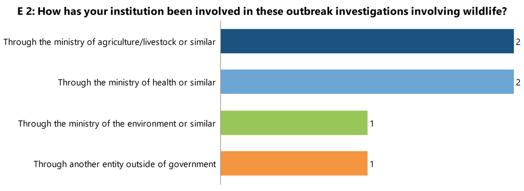

| Institutions | Through which entity |
| --- | --- |
| PREDICT | Through the Ministry of Livestock/Agriculture, the Ministry of Environment and the Ministry of Health |
| EBO SURSY | Through the Ministry of Livestock/Agriculture or similar |
| CERFIG | Through another non-governmental entity |
| Ministry of the Environment | Through the Ministry of Health |

#### E_3: Please list the exact names of the entities you have collaborated with during outbreak investigations

| Institutions | Entities collaborated with |
| --- | --- |
| PREDICT | National One Health Platform, FAO and University of California Davis, |
| Centre de Recherche et de Formation en Infectiologie de Guinée (CERFIG) | National Directorate of Veteran Services, Environmental Services (Conservatives) |
| Ministry of the Environment | The Community, the One Health Platform, the Lassa Fever Project. |

1 NA

#### E_4: Please select the types of wildlife you have investigated in outbreak investigations. Please select all that apply/E_4.1: If Other, please specify

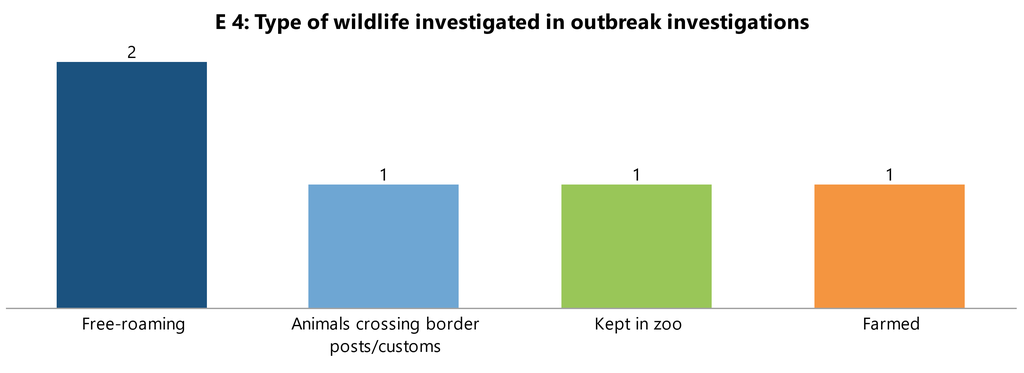

| Institutions | Types of wildlife investigated |
| --- | --- |
| PREDICT | Free-roaming |
| EBO SURSY | Animals crossing border posts/customs |
| CERFIG | Free-roaming and Farmed animals |
| Ministry of the Environment | Kept in zoos |

#### E_5: Please list the species, genus, family, or order of the wild mammals and birds you have investigated in outbreak investigations.

| Institutions | Types of wildlife investigated |
| --- | --- |
| PREDICT | Bats, Rodents, Small ruminants and Pigs |
| EBO SURSY | Mammals and birds |
| CERFIG | Chiroptera and rodents |
| Ministry of the Environment | Mice, bats, chimpanzees, Cephalophus spp |

#### E_6: Please list the diseases that were suspected or confirmed in the outbreak investigations you have participated

| Institutions | Diseases suspected or confirmed in the outbreak investigations |
| --- | --- |
| PREDICT | Ebola virus disease |
| EBO SURSY | Ebola virus disease and avian influenza |
| CERFIG | Ebola virus disease and Marburg fever |
| Ministry of the Environment | Ebola virus disease, Lassa fever and Anthrax |

#### E_7: Were your institution involved in collecting samples from wild mammals or birds during outbreak investigations?

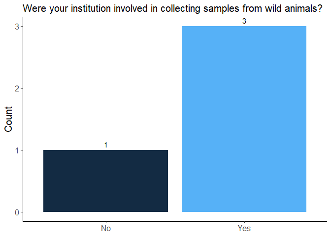

- Note: PREDICT, EBO SURSY and CERFIG collected samples from wild animals in outbreak investigations.

#### E_7.1: If yes, which types of samples have you collected.Please select all that apply.

1 NA

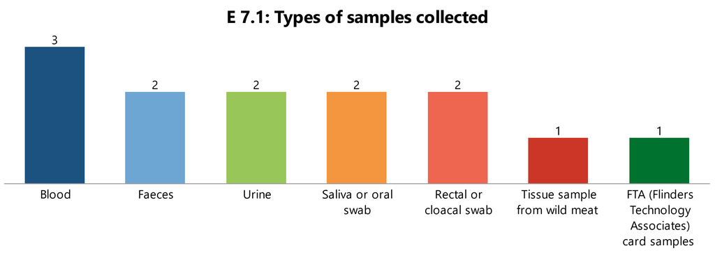

#### E_8: Was it possible to conduct laboratory tests to confirm the disease(s) in wildlife during the outbreak investigations

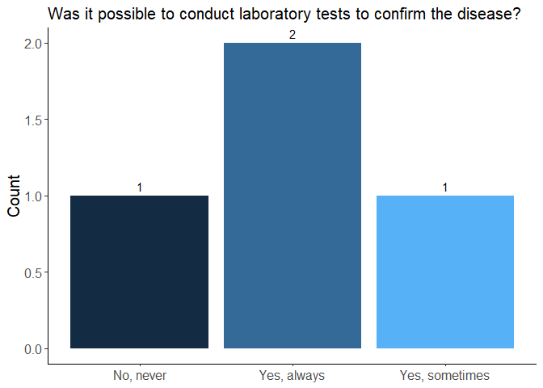

- Note: PREDICT and EBO SURSY replied ‘Yes, always’. CERFIG replied ‘No, never’ and the Ministry of the environment replied ‘Yes, sometimes’.

#### E_8.1: What type of diagnostic tests were you able to conduct in laboratories within the country in past investigations in wildlife?

| Institutions | type of diagnostic tests |
| --- | --- |
| EBO SURSY | Elisa, PCR |

2 NAs

- Note: One respondent replied that the tests were conducted outside the country

#### E_8.2: Please list the name of the laboratories where you conducted the tests.

| Institutions | laboratories |
| --- | --- |
| PREDICT | UC-Davis One Health and Veterinary Medicine Institute Laboratory |
| EBO SURSY | LNFH and LCVD |
| Ministry of the Environment | LCVD and Laboratoire Fièvre Hémoragique Nongo Conakry |

1 NA

- Note: LCVD: Laboratoire Central Vétérinaire Diagnostic

#### E_8.3: Were the diagnostic tests done in laboratories within the country validated for the targeted animals?

EBO SURSY - No

3 NA

#### E_8.4: What type of tests were you able to conduct in laboratories outside the country

| Institutions | type of diagnostic tests |
| --- | --- |
| PREDICT | Elisa, PCR |

2 NA

- Note: one respondent replied ‘I don’t know’

#### E_8.5: Please list the overseas laboratories where you conducted the tests

| Institutions | laboratories |
| --- | --- |
| PREDICT | UC-Davis One Health and Veterinary Medicine Institute Laboratory |
| Ministry of the Environment | The Laboratory of California |

- Note: one respondent replied ‘I don’t know’

1 NA

#### E_8.6: Were the diagnostic tests done in overseas laboratories validated for the targeted animals?

| Institutions | Tests done in overseas laboratories validated? |
| --- | --- |
| PREDICT | Yes |
| EBO SURSY | No |

2 NA

#### E_10: Was data from these investigations shared with any government entity? If no, please jump to question 10.4.

PREDICT and EBO SURSY share data with government entities

2 NA

- note: one of the respondents that didn’t reply to this questions answered the following questions, so perhaps it was a mistake.

**E_10.1: If yes, How is the data shared?**

| Institutions | How data is shared |
| --- | --- |
| PREDICT | Rapports ecrits |
| EBO SURSY | Papier ou internet |
| Ministry of the Environment | E-mails |

**E_10.2:If yes, How often is the data shared?**

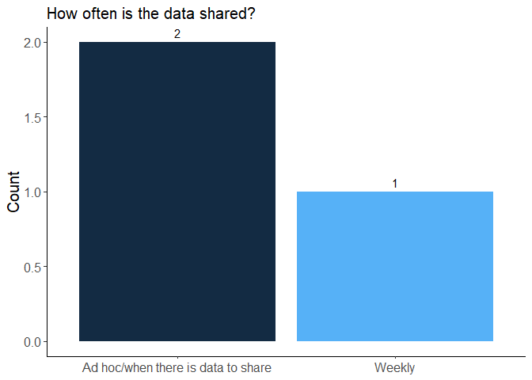

- Note: PREDICT and EBO SURSY share data Ad Hoc, the Ministry of the Environment shares data regularly (weekly)

1 NA

**E_10.3: If yes, please specify which entity (e.g. Ministry of Agriculture, Ministry of the Environment, National One Health Platform, etc.). Please use the exact name of the entity(ies) in your country.**

| Institution | Entities the data is shared with |
| --- | --- |
| PREDICT | The National Agency for Health Security and Ministry of Health |
| EBO SURSY | OH platform |
| Ministry of the Environment | The Ministry of livestock (National Veterinary Service), Ministry of Health (ANSS), Ministry of the Environment (OGPR) and Guinean Office of Parksand Reserves |

## Section F - Trainings on wild mammals and birds

### Section F.1: trainings or guidelines on diseases in wild mammals or birds.

1 Activity reported:

- EBO SURSY will provide training on diseases in wild mammals and birds to Heads of veterinary posts, nature conservationists and heads of human health posts, if it is validated by the central structure.

#### F_1.1: Do this row refer to a guideline or training?

- Training

#### F_1.1.b.i: If training, approximately how many people in the country has your institution trained on this topic? If possible, please specify by institution (e.g. 5 from the wildlife authority, 4 from ABC university)

| Number of people trained | Freq |
| --- | --- |
| Heads of veterinary posts, nature conservationists and heads of human health posts | 1 |

#### F_1.1.b.ii: If training, Is this training currently available?

Training will be available in the future

#### F_1.4: Please share any additional relevant information

“If it is validated by the central structure”

### Section F.2: Trainings or guidelines on the capture and manipulation of wild mammals or wild birds for disease investigation or research.

2 activities reported from PREDICT and EBO SURSY:

- EBO SURSY will provide training onon the capture and manipulation of wild mammals or wild birds for disease investigation or research to Veterinarians and nature conservationists, after it is validated.
- PREDICT developed a Guideline in september of 2015, about the capture and manipulation of Bats, Rodents, Pigs and Small Ruminants. Regarding the discovery of a 6th Ebola virus: Bombali Virus in Sierra Leone and Guinea and Marburg in Sierra Leone. Available at: [Advancing Global Health Security at the Frontiers of Disease Emergence](https://ohi.vetmed.ucdavis.edu/sites/g/files/dgvnsk5251/files/inline-files/P2%20EXECUTIVE%20SUMMARY%20-%20FINAL%20JAN%202021%20-%20WEB.pdf)

#### F_2.1: Does this row refer to a guideline or training?

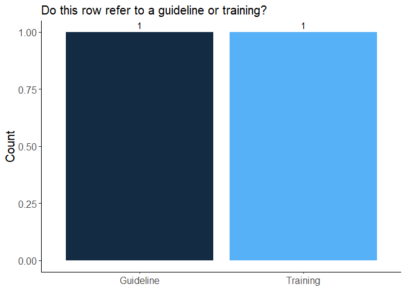

**Institutions that have developed guidelines**

| Institutions that have developed guidelines or plan to do so | Freq |
| --- | --- |
| PREDICT | 1 |

**Institutions that provided trainings**

| Institutions that have delivered trainings or plan to do so | Freq |
| --- | --- |
| EBO SURSY | 1 |

#### F_2.1.a: If guideline, when was this guideline published or when do you plan to release this guideline?

| Publication date | Freq |
| --- | --- |
| 2015-09-01 | 1 |

#### F_2.b.i: If training, Approximately how many people in the country has your institution trained on this topic? If possible, please specify by institution (e.g. 5 from the wildlife authority, 4 from ABC university)

| Number of people trained | Freq |
| --- | --- |
| Veterinarians and nature conservationists | 1 |

#### F_2.b.ii: If training, Is this training currently available?

No, but it will be available in the future.

#### F_2.2: Please specify the species, genus, family, or order of the animals covered by the guideline or training

*Guidelines*

| Animals covered by the guideline | Freq |
| --- | --- |
| Bats; Rodents; Pigs and Small Rumunants | 1 |

#### F_2.3: Please share any relevant additional information

*Trainings*

| Additional relevant information - training | Freq |
| --- | --- |
| After data validation | 1 |

*Guidelines*

| Additional relevant information - guideline | Freq |
| --- | --- |
| Discovery of a 6th Ebola virus: Bombali Virus in Sierra Leone and Guinea and Marburg in Sierra Leone | 1 |

### Section F.3: Trainings or guidelines on the collection, handling, transportation, and storage of clinical samples (blood, swab, urine, etc.) from wild mammals or wild birds.

2 activities reported

- EBO SURSY will provide training on the on the collection, handling, transportation, and storage of clinical samples to Veterinarians and nature conservationists, for investigation of Ebola and Avian Influenza. Training will be available in the future, and will be provided for Rectal or cloacal swab, Nasal discharge or nasal swab.
- PREDICT will provide training on the collection, handling, transportation, and storage of clinical samples, regarding Emerging diseases in bats, Rodents, Small Rumunants and Pigs. Training will be available in the future, and will be provided for Saliva or oral swab, Rectal or cloacal swab, blood, Feces taken from the rectum/cloaca, and tissue samples.

#### F_3.1: Does this row refer to a guideline or training?

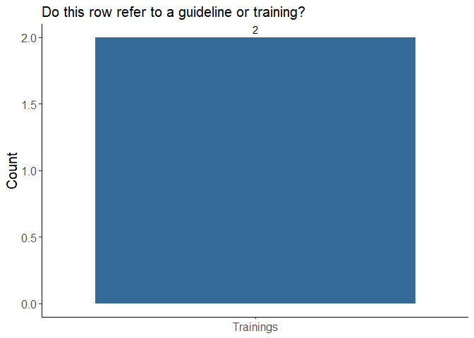

*Institutions that provided trainings*

| Institutions that have delivered trainings or plan to do so | Freq |
| --- | --- |
| EBO SURSY | 1 |
| PREDICT | 1 |

#### F_3.1.b.i: If training, approximately how many people in the country has your institution trained on this topic? If possible, please specify by institution (e.g. 5 from the wildlife authority, 4 from ABC university)

- Note: PREDICT expects to train 45 people. While EBO SURSY mentioned that the training will be provided to veterinarians and nature conservationists.

#### F_3.1.b.ii: If training, Is this training currently available?

Both institutions informed that the trainings will be available in the future.

#### F_3.2: Please specify for which disease or pathogen covered by the guideline or training

| Institution | Disease or pathogen covered by the training |
| --- | --- |
| PREDICT | Emerging diseases |
| EBO SURSY | Ebola and avian influenza |

#### F_3.3: Please specify for which species, genus, family or order covered by the guideline or training

| Institution | Specify for which wild animal |
| --- | --- |
| PREDICT | Bats, Rodents, Small Rumunants and Pigs |

#### F_3.4: Please specify for which type of sample.Please select all that apply

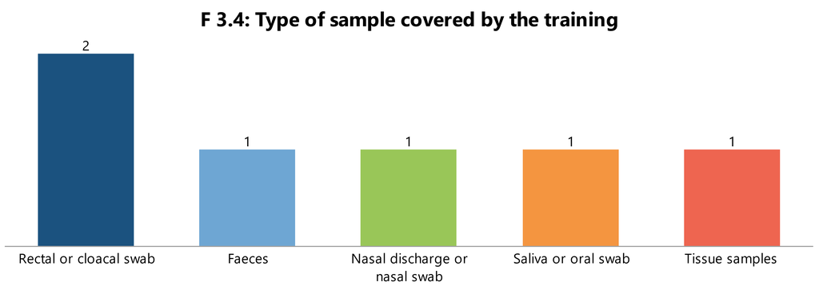

| Institution | Specify for which type of sample |
| --- | --- |
| PREDICT | Saliva or oral swab, Rectal or cloacal swab, blood, Feces taken from the rectum/cloaca, tissue samples |
| EBO SURSY | Rectal or cloacal swab,Nasal discharge or nasal swab |

#### F_3.5: Please share any relevant additional information

EBO SURSY - informed that training will be provided after validation

### Section F.4: Trainings or guidelines on the collection, handling, transportation and storage of environmental samples of wild mammals or wild birds for the detection of infectious diseases.

1 Activity reported:

- EBO SURSY will provide trainings about the collection, handling, transportation and storage of environmental samples (Faeces and Surface swabs) to veterinarians and nature conservationists, for Ebola and avian influenza, after validation.

#### F_4.1: Does this row refer to a guideline or training

Training provided by EBO SURSY

#### F_4.1.b.i: If training, approximately how many people in the country has your institution trained on this topic? If possible, please specify by institution (e.g. 5 from the wildlife authority, 4 from ABC university)

Training will be provided for Veterinarians and nature conservationists

#### F_4.1.b.ii: If training, Is this training currently available?

Training will be available in the future

#### F_4.3: Please specify for which disease or pathogen covered by the guideline or training

Ebola and avian influenza

#### F_4.4: Please specify for which type of sample. Please select all that apply.

Faeces, Surface swabs

#### F_4.5: Please share any relevant additional information

Training will be provided after validation

## Section F.5: Trainings or guidelines on the necropsy of wild mammals or wild birds

#### F_5: Between 2015 and now, has your institution ever delivered any training or developed guidelines since 2015 on the necropsy of wild mammals or wild birds or does it plan to do so?

1 activity reported.

- EBO SURSY will provide training on the necropsy of wild mammals, to veterinarians and nature conservationists.

#### F_5.1: Does this row refer to a guideline or training

Training provided by EBO SURSY

#### F_5.1.b.ii: If training, approximately how many people in the country has your institution trained on this topic? If possible, please specify by institution (e.g. 5 from the wildlife authority, 4 from ABC university)

Training will be provided for Veterinarians and nature conservationists

#### F_5.1.b.iii: If training, Is this training currently available?

No, but it will be available in the future

## Section F.6: Trainings or guidelines on laboratory tests for infectious diseases in wildlife

2 activities reported:

- EBO SURSY will provide trainings about laboratory tests (Serological and Pathogen detection) for infectious diseases in wildlife for Veterinarians and nature conservationists, regarding the diagnosis of Ebola and Avian influenza, and will be available in the future.
- PREDICT will provide training about laboratory tests (Serological and Pathogen detection) for the diagnosis of Rabies, Ebola, Anthrax and Avian Influenza to 15 people from the Central Laboratory of Veterinary Diagnostics of Conakry. Trainings will focus on Bats and Rodents and will be available in the future.

#### F_6.1: Does this row refer to a guideline or training

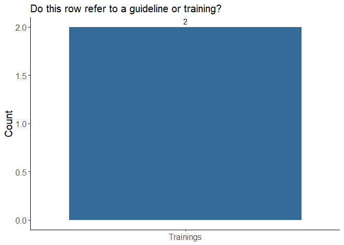

#### F_6.1.b.i: If training, approximately how many people in the country has your institution trained on this topic? If possible, please specify by institution (e.g. 5 from the wildlife authority, 4 from ABC university)

- Note: PREDICT expect to train 15 people from the Central Laboratory of Veterinary Diagnostics of Conakry. While EBO SURSY mentioned that the training will be provided to veterinarians and nature conservationists.

#### F_6.1.b.ii: If training, Is this training currently available?

Both institutions reported that the trainings will be available in the future.

#### F_6.2: Please specify for which disease or pathogen covered by the guideline or training

| Institution | Disease or pathogen covered by the training |
| --- | --- |
| PREDICT | Rabies, Ebola, Anthrax and Avian Influenza |
| EBO SURSY | Ebola and Avian Influenza |

#### F_6.3: If relevant, please specify for which species, genus, family, or order of animal

PREDICT specified that the training will be conducted regarding Bats and Rodents.

#### F_6.4: Please select the type of test covered by the guideline or training.Please select all that apply.

Both institutions will provide training for Serological tests and Pathogen detection.

#### F_6.5: Please share any relevant additional

EBO SURSY - After validation

## Section F.7: Trainings or guidelines on biosafety/biosecurity measures involving wildlife (during outbreak investigations, for carcass disposal, among others)

3 activities reported:

#### F_7.1: Does this row refer to a guideline or training

All activities reported are trainings

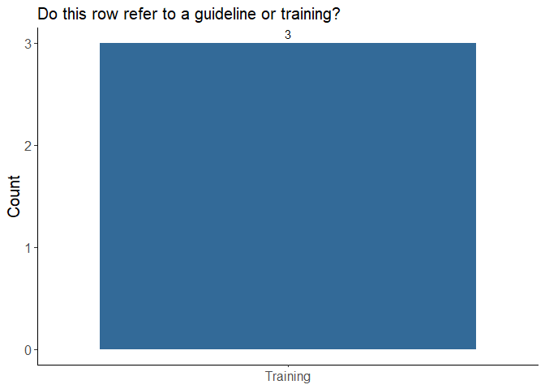

*Institutions that provided trainings*

| Institutions that have delivered trainings or plan to do so | Freq |
| --- | --- |
| EBO SURSY | 1 |
| Ministère de L’Environnement | 1 |
| PREDICT | 1 |

#### F_7.1.b.i: If training, approximately how many people in the country has your institution trained on this topic? If possible, please specify by institution (e.g. 5 from the wildlife authority, 4 from ABC university)

| Number of people trained | Freq |
| --- | --- |
| PREDICT | 10 doctors; 14 veterinarians; 8 natural resources agents |
| EBO SURSY | Veterinarians and conservationists of nature |
| Ministry of the Environment | 310 Agents and managers (2018-2020) |

#### F_7.1.b.ii: If training, Is this training currently available?

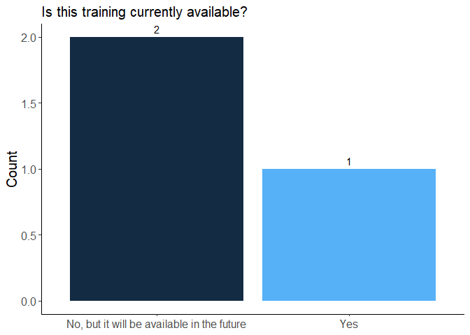

- Note: The training of the Ministry of the Environment is still available, while for EBO SURSY and PREDICT the training will be available in the future.

#### F_7.2: Please select the relevant biosafety/biosecurity topic covered by the guideline or training. Please select all that apply.

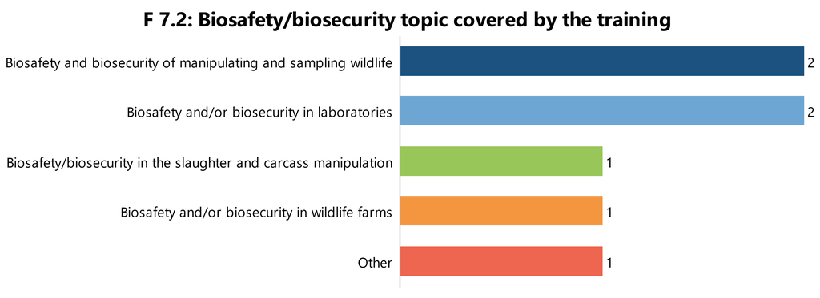

| Institution | Topic of Biosafety/Biosecurity training |
| --- | --- |
| PREDICT | Handling and sampling wildlife, Biosecurity/Biosafety in laboratories |
| EBO SURSY | Handling and sampling wildlife, Biosecurity/biosecurity in laboratories, Biosafety/biosecurity during slaughter and handling of wild animal carcasses, Biosafety/biosecurity in wild animal farming |
| Ministry of the Environment | Management of dead animals from zoonoses (Anthrax, lassa fever) |

#### F_7.3: Please share any relevant additional information

EBO SURSY - After validation